# Model Checking

Julia Fukuyama

Simulation-Based Inference · Lecture 9

## Today

So far, we have mostly asked how to estimate parameters and quantify uncertainty about them.

Today we ask: is the model we fit any good?

## Recall what we did for parametric bootstrap

In the parametric bootstrap, we replace the unknown truth $P_{\theta_0}$ with the fitted model $P_{\hat\theta}$:

$$Y^{*(b)}\sim P_{\hat\theta}.$$

This tells us how our estimator would behave **if the fitted model were generating the data**, which gave us an approximation to the sampling distribution of the estimator.

Today, we’ll use the same sorts of simulated data to check whether the model “fits” the data.

## What does it mean for a model to fit?

- Different from getting a precise parameter estimate
- If the bootstrap distribution of $\hat \theta$ is very narrow, then the interpretation is that the estimation procedure would give similar answers across repeated datasets from $P_{\hat \theta}$. This doesn’t tell us much about whether the fitted model will reproduce aspects of the data we didn’t use for fitting.
- Model “fit” can be quantified in different ways, but essentially the question is: for any characteristic of the data that we can observe, does the fitted model give values that are roughly in line with the observed values?

The two questions:

| Question | Procedure |
| --- | --- |
| How much would $\hat\theta$ vary if the fitted model generated new datasets? | Parametric bootstrap |
| Can the fitted model generate datasets resembling the observed one? | Model checking |

## The basic simulation experiment

Choose a feature of the data, $T(Y)$, that we want to check.

1. Fit the model:
   $$\hat\theta=h(Y_{\mathrm{obs}}).$$
2. Simulate replicated datasets:
   $$Y^{\operatorname{rep},(b)}\sim P_{\hat\theta}.$$
3. Calculate the same feature in every dataset:
   $$T_{\mathrm{obs}}=T(Y_{\mathrm{obs}}),
   \qquad
   T^{\operatorname{rep},(b)}=T(Y^{\operatorname{rep},(b)}).$$
4. Compare $T_{\mathrm{obs}}$ with the distribution of the replicated values.

## What must stay the same?

The replicated data should reproduce the original data-collection experiment:

- the same sample size;
- the same predictor values or experimental design, when those are treated as fixed;
- the same observation schedule;
- the same missing-data or censoring mechanism, if it is part of the analysis;
- the same preprocessing and calculation of $T$.

Otherwise, differences between the observed and replicated data might come from changing the experiment rather than from a failure of the model.

## What makes a useful check?

A useful check should be:

- **Observable:** We can calculate it from both the real and simulated data.
- **Relevant:** It describes something scientifically or practically important.
- **Capable of failing:** It was not automatically forced to agree during fitting.
- **Diagnosable:** If it fails, the direction of failure helps us understand what the model is missing.

There is no single universally best check. Different checks probe different possible failures.

## Why not check the summaries we fitted?

Suppose we chose $\hat\theta$ specifically to make

$$s(Y_{\mathrm{obs}})
\approx
\overline{s(Y_{\hat \theta})}.$$

Discovering afterward that these summaries agree is not much evidence for the model. We chose the parameters to make them agree.

## A check does not need to estimate the parameter well

For estimation, we want a summary whose distribution changes when $\theta$ changes.

For model checking, we want a feature that represents a consequence of the model that could be wrong; it doesn’t have to change with the paramater we’re estimating.

## Section 1: A Normal location-scale model

Start with our very simple model from before:

$$Y_i\stackrel{\mathrm{iid}}{\sim}N(\mu,\sigma^2).$$

We are measuring one quantity 500 times, and we fit $\mu$ and $\sigma$ to the measurements.

The story this time is that we’re observing some quality of a manufacturing process (maybe the location of a pre-drilled hole in a piece of Ikea furniture).

Most of the time, the hole is in the right place, but a small minority of the time the machine/worker messes up and you see a much wider spread in the measurements.

## The observed measurements

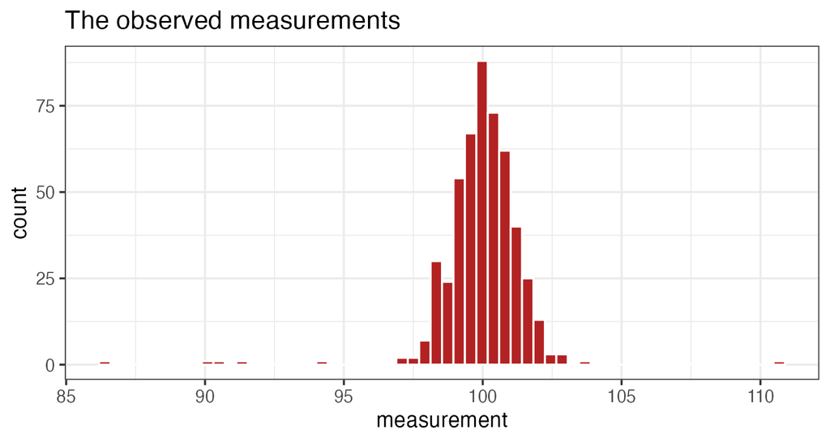

Almost all of the readings sit in a tight band. A handful are far away.

## The fitted model

Suppose we fit the model somehow and obtain $\hat\mu$ and $\hat\sigma$.

It does not matter for what follows how we got them.

The fitted generative model is

$$Y_i^{\operatorname{rep}}\stackrel{\mathrm{iid}}{\sim}
N(\hat\mu,\hat\sigma^2),$$

and we can now simulate as many replicate datasets from it as we like.

## Simulate and compare

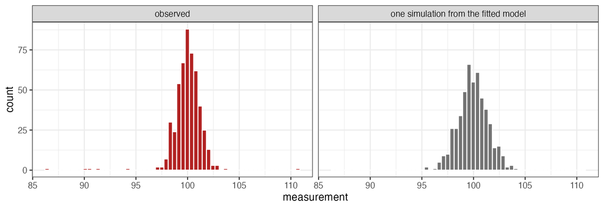

Two things are wrong at once: the simulated bulk is too wide, and the simulated data never produce a reading anywhere near the far ones.

## Another way to see this: Q-Q plot

Sort both datasets. Plot the $k$-th smallest simulated value against the $k$-th smallest observed value, for every $k$.

- Each point is one pair of matched order statistics (= (smallest in simulated, smallest in observed), or (second-smallest in simulated, second-smallest in observed), (k-th smallest in simulated, k-th smallest in observed)).
- The dashed line is where simulated $=$ observed. If the two datasets came from the same distribution, the points scatter around it.
- Points below the line mean the simulated values are *smaller* than the observed in that region, points above the line mean that the simulated values are larger than the observed in that region.
- At the upper tail (far right of the plot), simulated is substantially lower than observed.
- At the lower tail (far left of the plot), simulated is substantially higher than observed.
- Just below the median ($\approx$ 97-100), simulated is below observed, just above the median ($\approx$ 100-103), simulated is above observed.

## One simulation against the observed data

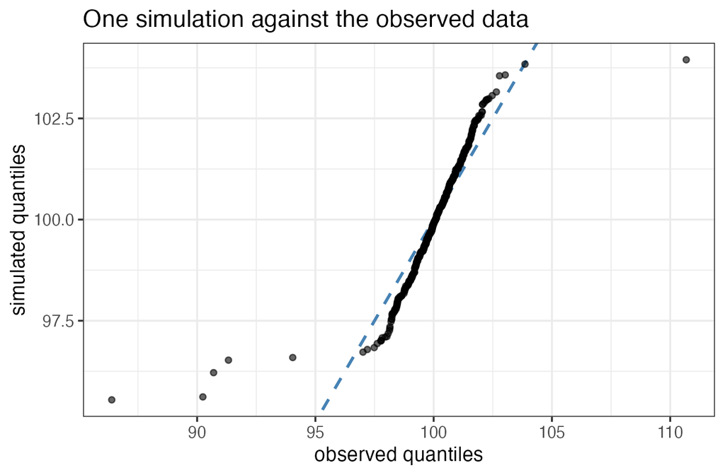

The bulk crosses the line steeply, and the extreme observed readings have no simulated counterpart.

## Is that just one unlucky simulation?

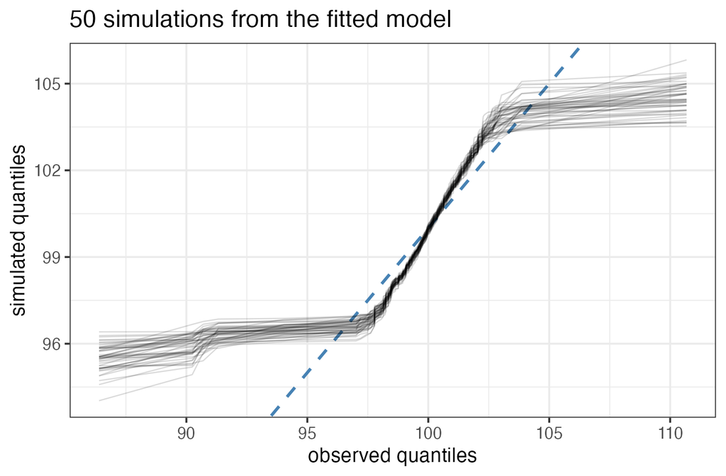

## A one-number summary

The plots show the discrepancy.

In this case, it’s clear by eye that there’s a huge discrepancy between observed and simulated, but if we want to be a bit more formal (or let a computer automate it), a statistic lets us measure it.

How far from the middle is the most extreme reading?

$$T(Y)
=
\max_i\left|Y_i-\operatorname{median}(Y)\right|.$$

## Simulate the reference distribution

For $b=1,\ldots,B$:

1. Simulate a dataset of the original size:
   $$Y^{\operatorname{rep},(b)}
   \sim N(\hat\mu,\hat\sigma^2).$$
2. Calculate
   $$T^{\operatorname{rep},(b)}
   =T(Y^{\operatorname{rep},(b)}).$$

Then compare $T(Y_{\mathrm{obs}})$ with the values the fitted model produces.

## The check in code

**R**

```r
outlier_distance <- function(y)
    max(abs(y - median(y)))

T_obs <- outlier_distance(y_obs)
T_rep <- replicate(2000,
    outlier_distance(rnorm(
        length(y_obs), mu_hat, sigma_hat)))
```

**Python**

```python
def outlier_distance(y):
    return np.max(np.abs(y - np.median(y)))


T_obs = outlier_distance(y_obs)
T_rep = np.array([
    outlier_distance(rng.normal(
        mu_hat, sigma_hat, len(y_obs)))
    for _ in range(2000)])
```

Everything specific to this check lives in `outlier_distance()`. The surrounding simulate-and-compare loop is the same in all three examples.

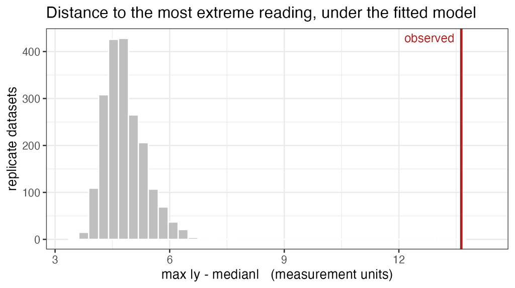

The observed value is far outside anything the fitted model produces.

## What did this check tell us?

The failure is not evidence that $\mu$ or $\sigma$ was estimated imprecisely.

Changing $\mu$ moves the distribution and changing $\sigma$ stretches it. Neither lets a Normal model produce a tight bulk *and* an occasional reading thirteen units away from the middle.

## The fitting method was not the important part

We could have obtained $(\hat\mu,\hat\sigma)$ using:

- closed-form maximum likelihood;
- numerical maximum likelihood;
- method of moments;
- simulated method of moments.

Once the fitted generative model is $N(\hat\mu,\hat\sigma^2)$, the same simulation-based check is available.

## Section 2: Linear regression

Consider the ordinary linear regression model

$$Y_i\mid x_i
\sim
N(\beta_0+\beta_1x_i,\sigma^2),$$

independently across observations.

This is a generative model for the responses, conditional on the predictor values.

After fitting $(\hat\beta_0,\hat\beta_1,\hat\sigma)$, we can simulate complete alternative response datasets from it.

## Reaction velocity and substrate concentration

The `Puromycin` data in R record reaction velocity at several substrate concentrations.

We will use one treatment group and start with the linear model

$$\operatorname{velocity}_i
=
\beta_0+
\beta_1\operatorname{concentration}_i+
\varepsilon_i,
\qquad
\varepsilon_i\stackrel{\mathrm{iid}}{\sim}N(0,\sigma^2).$$

Assume we have somehow obtained fitted values for $\beta_0$, $\beta_1$, $\sigma$.

## The observed data

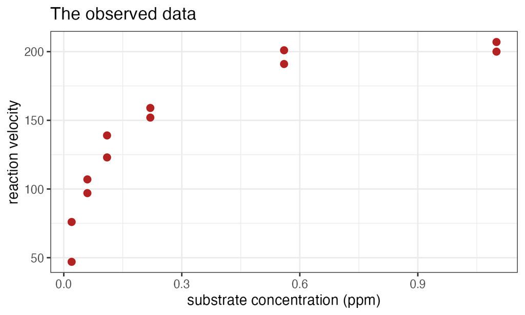

Velocity rises with concentration, steeply at first and then much less so.

## What experiment should we imitate?

The concentrations were part of the experimental design, so we hold them fixed.

For each replicate dataset, simulate

$$Y_i^{\operatorname{rep},(b)}
\sim
N\left(
\hat\beta_0+\hat\beta_1x_i,
\hat\sigma^2
\right)$$

at exactly the observed values $x_1,\ldots,x_n$.

We are asking what other response datasets could have occurred under the fitted line in this same experiment.

## Simulate and compare

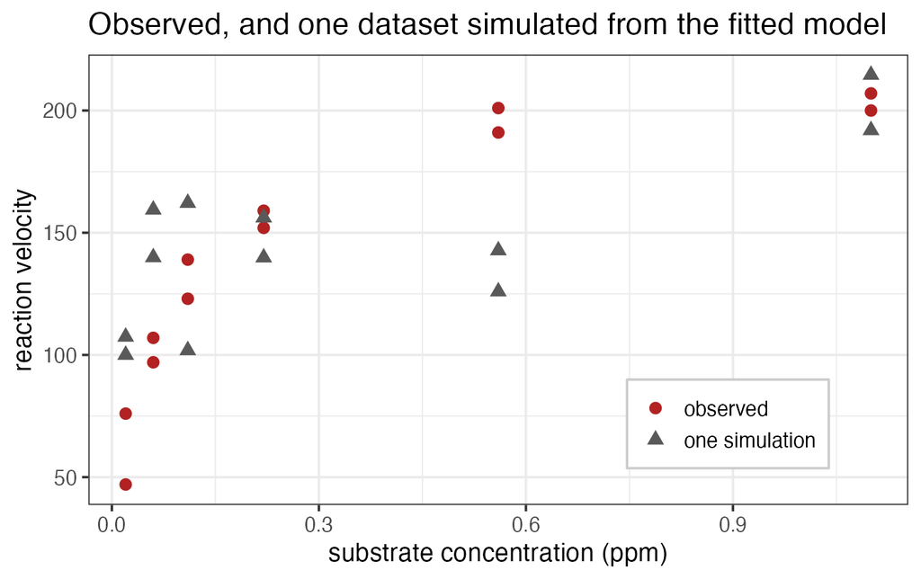

## Many simulations at once

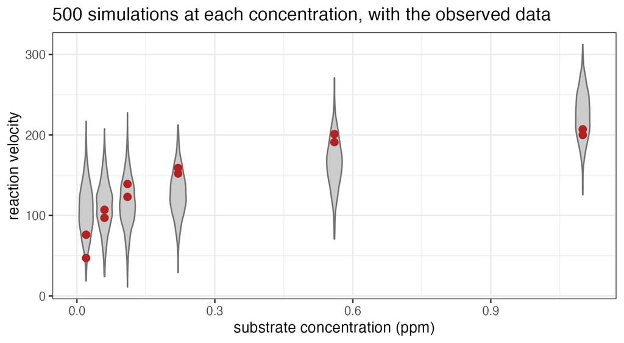

Each grey shape is the distribution of simulated velocities at that concentration.

## Averaging the runs at each concentration

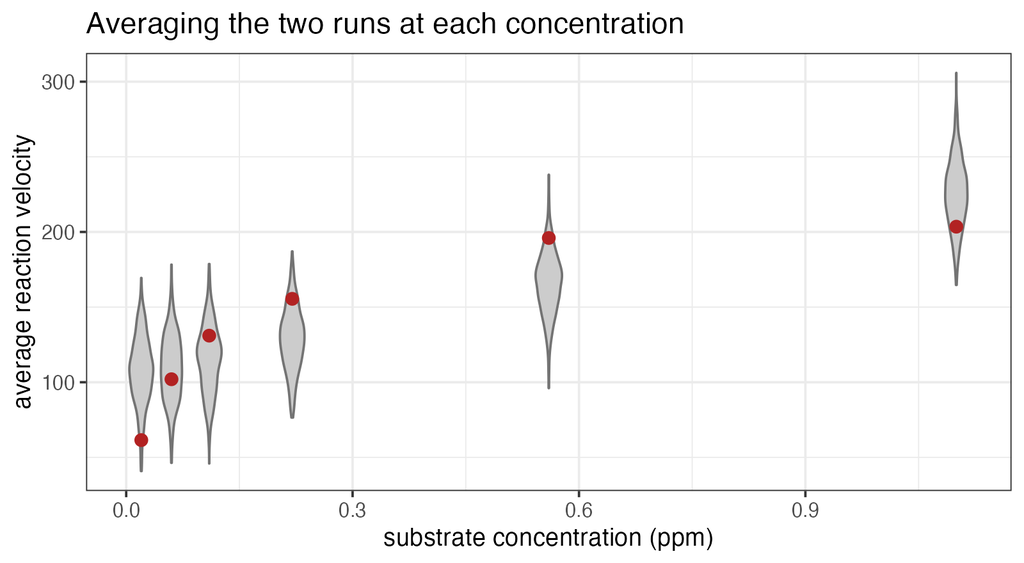

Each concentration was run twice and averaged, and the red dots are the average of the observed data at each concentration.

## One potential discrepancy

Every concentration was run exactly twice, and so we can measure the amount of noise using the absolute difference between the two observations at a given concentration.

$$T(Y)=\sum_{\text{concentrations }c}
\left|Y_{c,1}-Y_{c,2}\right|.$$

We can compare observed and simulated on this statistic.

## The pairs check in code

**R**

```r
pair_spread <- function(y)
    sum(abs(tapply(y, puro$conc, diff)))

T_obs <- pair_spread(puro$rate)
T_rep <- replicate(2000,
    pair_spread(rnorm(nrow(puro),
        fitted(fit), summary(fit)$sigma)))
```

**Python**

```python
def pair_spread(y):
    return sum(abs(np.diff(y[conc == c])[0])
               for c in cs)


T_obs = pair_spread(rate)
T_rep = np.array([
    pair_spread(rng.normal(fitted, sigma_lm))
    for _ in range(2000)])
```

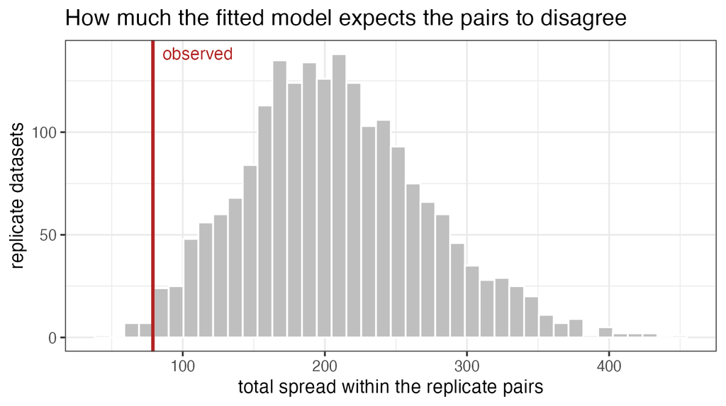

## Two different ways to see one failure

The violin plots and this statistic detect the same defect in different ways:

- the violins show the true mean function bending where the line is straight;
- the pairs show the noise estimate inflated to cover that bend.

In this case, it’s a bit easier to check on the discrepancy in the noise.

## How could we improve the model?

The straight-line fit does not explain the data well.

We need some sort of a curve.

A scientifically motivated revision might use a Michaelis-Menten curve,

$$E(Y\mid x)
=
\frac{V_{\max}x}{K+x},$$

rather than simply adding terms until the residual plot looks better.

## Familiar diagnostics fit this framework

Several classical regression diagnostics are model checks:

- residuals versus predictors check the conditional mean and variance;
- a Normal Q-Q plot checks the error distribution;
- residual autocorrelation checks independence;
- influential-point diagnostics check whether conclusions depend heavily on a few observations.

Simulation makes the reference comparison explicit and extends the same logic to models where standard diagnostic theory is unavailable.

## Section 3: A single-server queue

Return to the queue from Lecture 3.

In an $M/M/1$ queue:

$$A_i\stackrel{\mathrm{iid}}{\sim}\operatorname{Exponential}(\lambda),$$

$$S_i\stackrel{\mathrm{iid}}{\sim}\operatorname{Exponential}(\mu),$$

where $A_i$ is the time between arrivals, $S_i$ is a service time, and there is one first-come, first-served server.

## We have data and a fitted model

We observe one queue: the arrival times and the waiting times of a long run of customers.

Suppose we have fitted $\lambda$ and $\mu$ somehow, giving $\hat\lambda$ and $\hat\mu$. As before, how we fitted them does not matter here.

We can again use the fitted model to generate new queues and check whether the simulated queues look like the observed queues.

## The observed waiting times

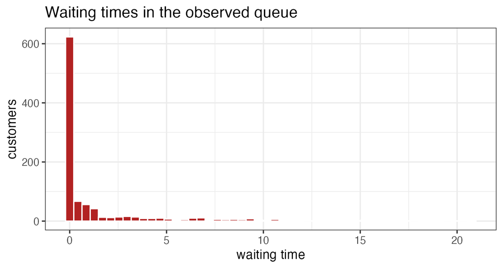

## Simulate and compare

Simulate one complete queue from the fitted model (same number of customers, same fitted rates) and put its waiting times beside the observed ones.

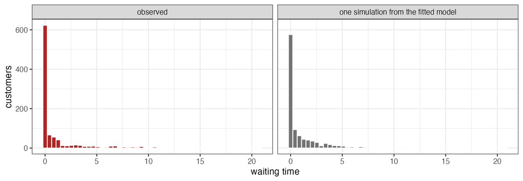

## The complete check

For $b=1,\ldots,B$:

1. Simulate interarrival times from $\operatorname{Exponential}(\hat\lambda)$.
2. Simulate service times from $\operatorname{Exponential}(\hat\mu)$.
3. Pass them through the queueing simulator.
4. Calculate the chosen summary (in this case mean waiting time across all customers in the queue).

## The queue check in code

**R**

```r
mean_wait <- function(q) mean(q$waiting)

T_obs <- mean_wait(queue_obs)
T_rep <- replicate(2000,
    mean_wait(simulate_queue(
        n_customers, lambda_hat, mu_hat)))
```

**Python**

```python
def mean_wait(q):
    return q["waiting"].mean()


T_obs = mean_wait(queue_obs)
T_rep = np.array([
    mean_wait(simulate_queue(
        n_customers, lambda_hat, mu_hat))
    for _ in range(2000)])
```

`simulate_queue()` is the Lecture 3 simulator. Only the choice of `mean_wait()` is new.

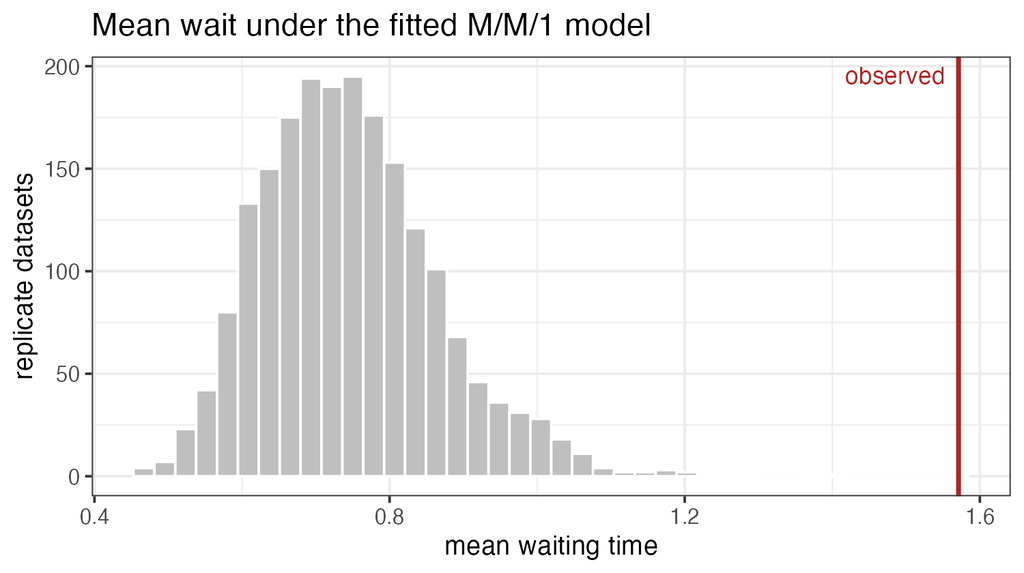

The fitted model expects a mean wait of about 0.74. The observed queue averages 1.57.

## What did this check tell us?

- Mainly that the model is insufficient to explain waiting times
- You would need to know a bit more about the model and play around with other possibilities to see how to fix it.
- In this case, it could be fixed by modifying the service-time distribution (the data were actually generated under a model where arrivals were from an exponential distribution but service times were from a distribution with heavier tails).

## What does a failure mean?

If the observed feature is unusual under the fitted model, several explanations are possible:

- the structural story is missing an important mechanism;
- a distributional assumption is wrong;
- the observation or sampling model is wrong;
- an important covariate has been omitted;
- the fitting or simulation code contains an error;
- the observed dataset is an unusual realization of an adequate model.

A useful check narrows these possibilities, but rarely identifies a unique replacement model by itself.

## What does passing a check mean?

If the observed feature looks ordinary relative to the simulations, then the model has reproduced that particular feature.

It does not follow that:

- the model is true;
- every other feature of the data is reproduced;
- the scientific mechanism is correct.

## What we saw

- Uncertainty quantification and model checking answer different questions.
- A generative model makes predictions beyond the quantities used to fit it.
- We check those predictions by simulating complete datasets and calculating the same features in observed and replicated data.
- A failed check is most valuable when it points toward a specific weakness in the model and a plausible revision.